# CS 699 Assignment 1

Katherine Rein

```r
# Import libraries
library(glue)
library(modeest)
library(dplyr)
library(fastDummies)
```

```r
library(ggplot2)
```

# Problem 1

## Question 1

Calculate the mean, median, and standard deviation (sample) of the age feature

```r
# Read in data
autism_data = read.csv('autism-adult.csv')

# Drop fully NA rows
autism_data <- autism_data[!apply(is.na(autism_data), 1, all), ]

# Remove 383 year old
autism_data = autism_data[autism_data$age != 383, ]

# Convert age to integer
autism_data$age = as.integer(autism_data$age)
# Calculate the mean median and standard deviation for the age feature
mean =  mean(autism_data$age, na.rm = TRUE)
median = median(autism_data$age, na.rm = TRUE)
stdev = sd(autism_data$age, na.rm = TRUE)

# Print answers
glue('Mean: {mean}')
```

```
## Mean: 29.1940085592011
```

```r
glue('Median: {median}')
```

```
## Median: 27
```

```r
glue('Standard Deviation (sample): {stdev}')
```

```
## Standard Deviation (sample): 9.71152590893556
```

```
After some preliminary data analysis, I noticed there was someone who was 383 years old
which seems impossible. I removed this entry before continuing on.
The mean of the data set is 29.20. The median is 27. The sample standard deviation is 9.71.
```

## Question 2

Determine Q1, Q2, and Q3 of age

```r
# Calculate Q1, Q2, Q3
quantile_vector = quantile(autism_data$age, probs = c(0.25, 0.5, 0.75), na.rm = TRUE)

# Store individually
Q1 = quantile_vector[1]
Q2 = quantile_vector[2]
Q3 = quantile_vector[3]

# Print
glue('Q1: {Q1}, Q2: {Q2}, Q3: {Q3}')
```

```
## Q1: 21, Q2: 27, Q3: 35
```

```
Q2 is the same as the median of the data set but I also recalculated it. Q1 is
21, Q2 is 27, and Q3 is 35.
```

## Question 3

Plot the boxplot of the age feature

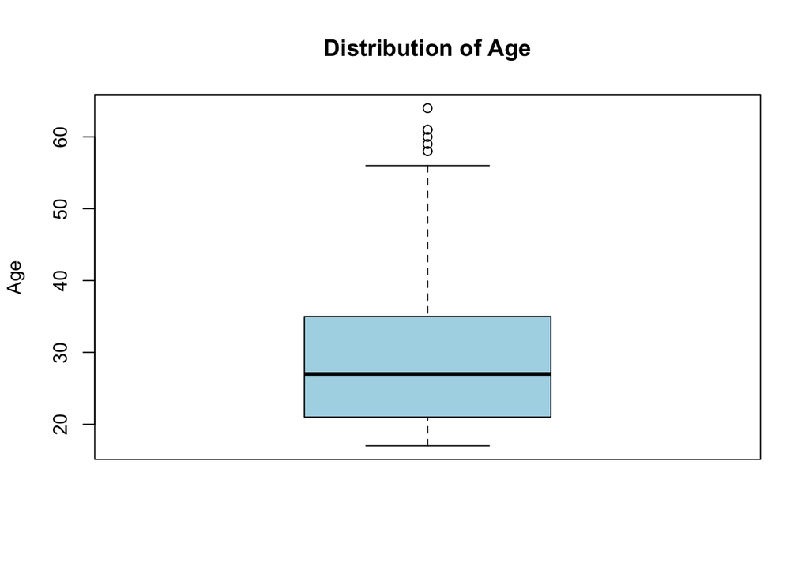

```r
# Plot Boxplot
boxplot(autism_data$age,
        main = "Distribution of Age", ylab = "Age",
        col = "lightblue", notch = FALSE, na.rm = TRUE)
```

## Question 4

Implement min-max rescaling on the age feature. Replace the original age feature with the rescaled result. Provide the rescaled age for the seventh observation in the data.

```r
# Find the minimum and maximum age
min_age = min(autism_data$age, na.rm = TRUE)
max_age = max(autism_data$age, na.rm = TRUE)

# Implement min‐max rescaling to the [0, 1] interval
# Formula: (x − min) / (max − min)
autism_data$age = (autism_data$age - min_age) / (max_age - min_age)

# Print seventh observation
seventh_obs = autism_data$age[7]
print(seventh_obs)
```

```
## [1] 0
```

```
For min-max rescaling I used a minimum value of 0 and max of 1. The seventh
observation is now 0. This means that before the data was rescaled it was the
minimum age.
```

## Question 5

Determine the mode of the country_of_res feature

```r
# Handle NAs
autism_data$country_of_res <- dplyr::na_if(autism_data$country_of_res, '')

# Create a frequency table of unique values
freq_loc <- table(autism_data$country_of_res, useNA = "no")

# Find the most frequent values of a vector
mode_loc <- modeest::mfv(autism_data$country_of_res, na_rm = TRUE)

# Concatenate frequencies and modes
list(frequencies = freq_loc, mode = mode_loc)
```

```
## $frequencies
##
##           'Costa Rica'       'Czech Republic'            'Hong Kong'
##                      1                      1                      1
##          'New Zealand'         'Saudi Arabia'         'Sierra Leone'
##                     80                      4                      1
##         'South Africa'            'Sri Lanka' 'United Arab Emirates'
##                      2                     14                     82
##       'United Kingdom'        'United States'             'Viet Nam'
##                     77                    113                      5
##            Afghanistan          AmericanSamoa                 Angola
##                     13                      2                      1
##              Argentina                Armenia                  Aruba
##                      2                      2                      1
##              Australia                Austria             Azerbaijan
##                     27                      4                      1
##                Bahamas             Bangladesh                Belgium
##                      2                      3                      3
##                Bolivia                 Brazil                Burundi
##                      1                      9                      1
##                 Canada                  Chile                  China
##                     15                      1                      1
##                 Cyprus                Ecuador                  Egypt
##                      1                      1                      3
##               Ethiopia                Finland                 France
##                      2                      1                     11
##                Germany                Iceland                  India
##                      4                      2                     81
##              Indonesia                   Iran                   Iraq
##                      1                      7                      1
##                Ireland                  Italy                  Japan
##                      5                      5                      1
##                 Jordan             Kazakhstan                Lebanon
##                     47                      3                      1
##               Malaysia                 Mexico                  Nepal
##                      5                      8                      1
##            Netherlands              Nicaragua                  Niger
##                     10                      1                      1
##                   Oman               Pakistan            Philippines
##                      1                      3                      4
##               Portugal                Romania                 Russia
##                      1                      3                      7
##                 Serbia                  Spain                 Sweden
##                      1                      3                      2
##                  Tonga                 Turkey                Ukraine
##                      1                      1                      2
##                Uruguay
##                      1
##
## $mode
## [1] "'United States'"
```

```
The mode of the country of residence column is United States with 113 entries.
```

## Question 6

Review the ethnicity feature. You will notice several missing values in this feature. Determine a reasonable imputation for this feature. Explain what you are going to do and why. Then replace the original ethnicity feature with the imputed result.

```r
# Identify all categories used in the ethnicity feature
unique(autism_data$ethnicity)
```

```
##  [1] "White-European"    "Latino"            "?"
##  [4] "Others"            "Black"             "Asian"
##  [7] "'Middle Eastern '" "Pasifika"          "'South Asian'"
## [10] "Hispanic"          "Turkish"           "others"
```

```r
# Turn missing values into NA
autism_data$ethnicity <- dplyr::na_if(autism_data$ethnicity, '')

# Change all other values into one other value
autism_data <- autism_data %>%
  mutate(ethnicity = case_when(
    ethnicity == '?' ~ 'Other',
    ethnicity == 'others' ~ 'Other',
    ethnicity == 'Others' ~ 'Other',
    ethnicity == NA ~ 'Other',
    TRUE ~ ethnicity
  ))
```

```
After looking at all of the unique values for the ethnicity feature, I noticed
there were many entries that meant other. I then changed all of them to other.
This seemed like the best way to not overinflate one category (as we don't know
where these individuals came from).
```

## Question 7

Create a bar graph of your imputed ethnicity feature.

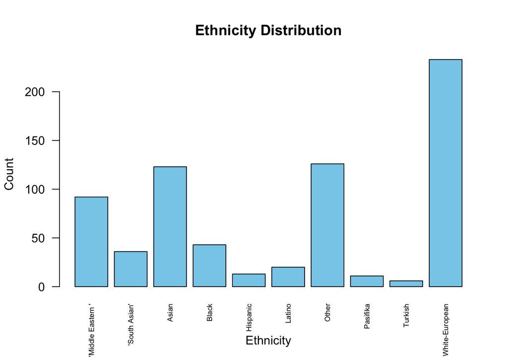

```r
barplot(table(autism_data$ethnicity),
        main = "Ethnicity Distribution",
        xlab = "Ethnicity",
        ylab = "Count",
        col = "skyblue",
        cex.names = 0.6,
        las = 2)
```

## Question 8

Implement dummy coding for the gender feature. Replace the original gender feature with the coded result. Provide the coded gender for the last ten observations in the data.

```r
# Ensure gender is treated as a categorical factor
autism_data$gender <- as.factor(autism_data$gender)

# One encoding of gender column
d <- fastDummies::dummy_cols(autism_data,
                             select_columns = "gender",
                             remove_selected_columns = TRUE,
                             remove_first_dummy = TRUE
                             )

# Show the last 10
coded_gender_last10 = tail(d[ , grep("^gender_", names(d)) ], 10)
coded_gender_last10
```

```
##  [1] 1 1 1 0 0 0 1 0 1 0
```

## Question 9

Identify which features in your data set are discrete and which are continuous.

```
From visual investigation, it seems that the following features are discrete:
A1_score - A10_score, gender, ethnicity, jaundice, autism, country of residence,
used app before, relation, and class ASD. The only continuous feature is age.
```

## Question 10

Identify which features in your data set are numeric and which are non-numeric. Compare with the discrete/continuous classification you just made and discuss the similarities and/or differences you see.

```r
# Convert blank strings to NA
autism_data <- mutate(autism_data, across(where(is.character), ~ dplyr::na_if(.x, '')))

# Identify column classes of the data
col_classes <- sapply(autism_data, class)

# Link classes and names
col_classes_df = data.frame(Column = names(autism_data), Class = col_classes)

print(col_classes_df)
```

```
##                          Column     Class
## A1_Score               A1_Score   integer
## A2_Score               A2_Score   integer
## A3_Score               A3_Score   integer
## A4_Score               A4_Score   integer
## A5_Score               A5_Score   integer
## A6_Score               A6_Score   integer
## A7_Score               A7_Score   integer
## A8_Score               A8_Score   integer
## A9_Score               A9_Score   integer
## A10_Score             A10_Score   integer
## age                         age   numeric
## gender                   gender    factor
## ethnicity             ethnicity character
## jaundice               jaundice character
## austim                   austim character
## country_of_res   country_of_res character
## used_app_before used_app_before character
## relation               relation character
## Class.ASD             Class.ASD character
```

```
The following columns are numeric: A1_Score - A10_Score and age. The non numeric
columns are: gender, ethnicity, jaundice, autism, country of residence, used app
before, relation, and Class ASD. The only difference between numeric and
continuous is that the A score columns are discrete data with numeric classes.
This makes them a numeric discrete feature which is unlike any other column.
```

## Question 11

After completing all requested tasks above, print the first 4 observations of the data.

```r
head(autism_data, n = 4)
```

|  | A1_Score | A2_Score | A3_Score | A4_Score | A5_Score | A6_Score | A7_Score | A8_Score | A9_Score | A10_Score | age | gender | ethnicity | jaundice | austim | country_of_res | used_app_before | relation | Class.ASD |
| --- | --- | --- | --- | --- | --- | --- | --- | --- | --- | --- | --- | --- | --- | --- | --- | --- | --- | --- | --- |
| 1 | 1 | 1 | 1 | 1 | 0 | 0 | 1 | 1 | 0 | 0 | 0.1914894 | f | White-European | no | no | 'United States' | no | Self | NO |
| 2 | 1 | 1 | 0 | 1 | 0 | 0 | 0 | 1 | 0 | 1 | 0.1489362 | m | Latino | no | yes | Brazil | no | Self | NO |
| 3 | 1 | 1 | 0 | 1 | 1 | 0 | 1 | 1 | 1 | 1 | 0.2127660 | m | Latino | yes | yes | Spain | no | Parent | YES |
| 4 | 1 | 1 | 0 | 1 | 0 | 0 | 1 | 1 | 0 | 1 | 0.3829787 | f | White-European | no | yes | 'United States' | no | Self | NO |

# Problem 2

## Question 1

Create a scatterplot of feature A1 vs. feature A5.

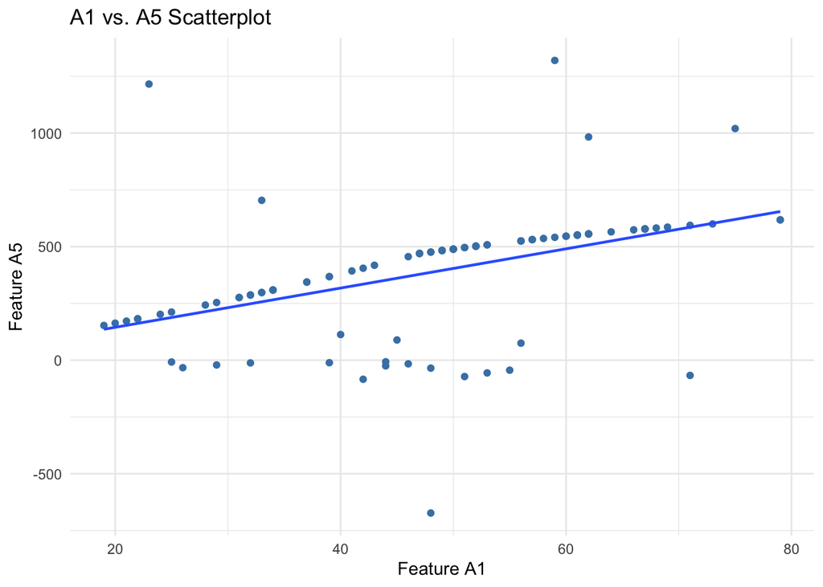

```r
# Read in data
corr_data = read.csv('correlation.csv')

# Drop NAs in both columns
corr_clean <- tidyr::drop_na(corr_data, A1, A5)

# Make all values numeric
corr_clean$A1 <- suppressWarnings(as.numeric(corr_clean$A1))
corr_clean$A5 <- suppressWarnings(as.numeric(corr_clean$A5))

# Create scatterplot
ggplot(corr_clean, aes(x = A1, y = A5)) +
  geom_point(color = "steelblue") +
  geom_smooth(method = "lm", se = FALSE, linewidth = 0.8) + labs(title = "A1 vs. A5 Scatterplot",
                                                                 x = "Feature A1",
                                                                 y = "Feature A5") + theme_minimal()
```

## Question 2

Compute the correlation matrix for all five features in the data set.

```r
# Create a vector of column names
cols = paste0("A", 1:5)

# Ensure all columns are numeric
for (v in cols) corr_data[[v]] <- suppressWarnings(as.numeric(corr_data[[v]]))

# Compute the Pearson correlation matrix
cor_mat <- cor(corr_data[cols], use = "pairwise.complete.obs", method = "pearson")

# Print correlation matrix
cor_mat
```

```
##           A1         A2        A3         A4         A5
## A1 1.0000000 0.17880899 0.2896419 0.17717981 0.45241040
## A2 0.1788090 1.00000000 0.4645427 0.34013541 0.04235286
## A3 0.2896419 0.46454268 1.0000000 0.29379683 0.19451370
## A4 0.1771798 0.34013541 0.2937968 1.00000000 0.06186254
## A5 0.4524104 0.04235286 0.1945137 0.06186254 1.00000000
```

## Question 3

Identify the strongest correlation in the data set. Which factors are involved? Is it a positive correlation or a negative correlation?

```r
# Switch diagonal to NA
diag(cor_mat) <- NA

# Find the max correlation value
max_val = max(cor_mat, na.rm = TRUE)

# Find the position of that max value
which(cor_mat == max_val, arr.ind = TRUE)
```

```
##    row col
## A3   3   2
## A2   2   3
```

```
The strongest correlation is 0.465 which correlates A3 and A2. This is a positive
correlation because the number is positive.
```

## Question 4

Implement z-score normalization on all features in the data set

```r
corr_data[cols] <- as.data.frame(scale(corr_data[cols], center = TRUE, scale = TRUE))
```

## Question 5

Compute the correlation matrix for all five normalized features in the data set. Compare this correlation matrix with the matrix you obtained earlier and discuss the similarities and/or differences you see.

```r
# Create a vector of column names
cols = paste0("A", 1:5)

# Ensure all columns are numeric
for (v in cols) corr_data[[v]] <- suppressWarnings(as.numeric(corr_data[[v]]))

# Compute the Pearson correlation matrix
cor_mat <- cor(corr_data[cols], use = "pairwise.complete.obs", method = "pearson")

# Print correlation matrix
cor_mat
```

```
##           A1         A2        A3         A4         A5
## A1 1.0000000 0.17880899 0.2896419 0.17717981 0.45241040
## A2 0.1788090 1.00000000 0.4645427 0.34013541 0.04235286
## A3 0.2896419 0.46454268 1.0000000 0.29379683 0.19451370
## A4 0.1771798 0.34013541 0.2937968 1.00000000 0.06186254
## A5 0.4524104 0.04235286 0.1945137 0.06186254 1.00000000
```

```
The correlation matricies are identical. This makes sense because when we normalize
features we are already removing the affects of mean and standard deviation.
```